# lame Overview

Cassy Dorff, Shahryar Minhas, and Tosin Salau

2026-07-22

## Package Overview

The `lame` package provides tools for fitting **L**ongitudinal **A**dditive and **M**ultiplicative **E**ffects models to network data observed over time. If you study relationships between actors (countries trading with each other, legislators co-sponsoring bills, students forming friendships across semesters) and you have repeated observations of those relationships, `lame` is designed for you.

The modeling approach builds on the Additive and Multiplicative Effects (AME) framework developed by Peter Hoff, whose [`amen`](https://pdhoff.github.io/amen/) package provides the foundational cross-sectional implementation. `lame` extends that framework with:

- **Longitudinal data**: panel networks observed across multiple time periods, potentially with actors entering and leaving the sample.
- **Dynamic effects**: latent positions and baseline activity levels can evolve via AR(1) processes (`dynamic_uv` and `dynamic_ab`).
- **C++ acceleration**: core sampling routines in Rcpp/RcppArmadillo.
- **Bipartite networks**: two-mode networks (e.g., countries and treaties) with separate latent spaces for row and column nodes.
- **ggplot2-based diagnostics**: `trace_plot`, `gof_plot`, `ab_plot`, and `uv_plot` return standard ggplot2 figures you can theme and extend.
- **Standard S3 methods**: `coef()`, `confint()`, `fitted()`, `residuals()`, `predict()`, and `simulate()` work as you would expect from any R model object.

The package works with [`netify`](https://netify-dev.github.io/netify/) for data preparation.

### Migrating from `amen`

Both `amen` and `lame` export an `ame()` function; if both packages are attached, a startup message reminds you that unqualified `ame(...)` calls dispatch to whichever was attached last, so write `lame::ame(...)` to be explicit. Old `amen` scripts largely run unchanged – the most common porting fix is `family = "nrm"` becoming `family = "normal"` (the short forms are accepted as aliases, with a message), and `print =` is deprecated in favour of `verbose =`. The full mapping of argument and output differences lives in the *Migration from amen* sections of `?ame` and `?lame`.

## Application: Dutch College Friendships

To see how `lame` works in practice, we analyze the **Dutch college friendship network** (van de Bunt, van Duijn, and Snijders 1999), a panel of 32 students who arrived as strangers and rated each other’s friendship at seven time points. (We drop the cold-start first wave, when the students barely knew each other and almost no ties exist; six waves remain.) The substantive question is whether students sort by gender, smoking status, and academic program, and whether residual clustering remains once those covariates are absorbed.

The dataset includes:

- **Y**: directed friendship ratings on a -1 to 4 scale (-1 a negative/troubled relationship, 0 no or uncertain tie, 1-4 increasing friendship). We binarize any positive rating to a tie (`(Y > 0) * 1`), so the rare -1 ratings fold in with 0 as “no tie”.
- **X**: three node-level attributes: `male`, `smoker`, `program`.
- We construct three dyadic **homophily indicators** from the node attributes: `same_male`, `same_smoker`, `same_program`.

```r
library(lame)
library(ggplot2)
set.seed(6886)

data("dutchcollege")

n <- nrow(dutchcollege$Y)
T_all <- dim(dutchcollege$Y)[3]
actor_names <- sprintf("S%02d", seq_len(n))

# binarize and drop the cold-start wave (t = 1 has almost no ties)
Y <- lapply(2:T_all, function(t) {
    Yt <- (dutchcollege$Y[, , t] > 0) * 1
    diag(Yt) <- NA
    rownames(Yt) <- colnames(Yt) <- actor_names
    Yt
})
names(Y) <- paste0("t", 2:T_all)

# nodal covariates passed identically as sender and receiver
X_node <- dutchcollege$X
rownames(X_node) <- actor_names
Xrow <- lapply(seq_along(Y), function(t) X_node)
Xcol <- Xrow

# dyadic homophily indicators
same_male    <- outer(X_node[, "male"],    X_node[, "male"],    "==") * 1
same_smoker  <- outer(X_node[, "smoker"],  X_node[, "smoker"],  "==") * 1
same_program <- outer(X_node[, "program"], X_node[, "program"], "==") * 1
Xdyad_one <- array(0, dim = c(n, n, 3),
                   dimnames = list(actor_names, actor_names,
                                   c("same_male", "same_smoker", "same_program")))
Xdyad_one[, , 1] <- same_male
Xdyad_one[, , 2] <- same_smoker
Xdyad_one[, , 3] <- same_program
Xdyad <- lapply(seq_along(Y), function(t) Xdyad_one)
```

The friendship network’s average density rises across the panel as students settle in, though the trajectory is not monotone (density bounces between roughly 0.40 and 0.63 across the six waves):

```r
sapply(Y, function(y) round(mean(y, na.rm = TRUE), 2))
```

```
#>   t2   t3   t4   t5   t6   t7
#> 0.40 0.52 0.47 0.49 0.63 0.51
```

### Fitting the Model

We fit a binary probit AME model with sender random effects (`rvar`), receiver random effects (`cvar`), dyadic correlation (`dcor`), and a one-dimensional latent space (`R = 1`). The random effects capture sender heterogeneity (some students simply nominate more friends) and receiver heterogeneity (some students are nominated more often), while the latent space picks up residual clustering: students who befriend similar people for reasons the observed covariates do not capture. (Why `R = 1` and not 2? See the Latent Space section below.)

```r
fit <- lame(
    Y = Y,
    Xdyad = Xdyad,           # dyadic homophily indicators
    Xrow = Xrow,             # sender covariates
    Xcol = Xcol,             # receiver covariates
    family = "binary",       # binary probit model
    rvar = TRUE,             # sender random effects
    cvar = TRUE,             # receiver random effects
    dcor = TRUE,             # dyadic correlation (reciprocity)
    R = 1,                   # 1-D multiplicative latent space
    symmetric = FALSE,       # friendships are directed
    burn = 30,               # short burn-in for this worked example
    nscan = 150,             # compact post-burn-in run for the vignette
    odens = 10,              # thinning -> 15 stored draws
    posterior_opts = list(save_UV = TRUE),  # keep U/V draws: gives
                                            # latent_positions() real
                                            # posterior SDs below
    save_log_lik = TRUE,     # pointwise log-lik: feeds loo() at the end
    verbose = FALSE,
    plot = FALSE
)
```

### Interpreting the Results

```r
summary(fit)
```

```
#>
#> === Longitudinal AME Model Summary ===
#>
#> Call:
#> [1] "Y ~ dyad(same_male, same_smoker, same_program) + row(male, smoker, program) + col(male, smoker, program) + a[i] + b[j] + rho*e[ji] + U[i,1:1] %*% V[j,1:1], family = 'binary'"
#>
#> Time periods: 6
#> Family: binary
#> Mode: unipartite
#>
#> Note: STATIC fit pooled across 6 time periods --
#>   U, V, a, b are time-invariant; per-period predictions vary
#>   only through per-period covariates. For time-varying effects,
#>   refit with dynamic_uv = TRUE and/or dynamic_ab = TRUE.
#>
#> Regression coefficients:
#> ------------------------
#>                   Estimate StdError z_value p_value CI_lower CI_upper
#> intercept           -2.476    0.751  -3.295   0.001   -3.786   -1.179 ***
#> male_row             0.812    0.573   1.417   0.156   -0.163    1.636
#> smoker_row          -0.926    0.435  -2.127   0.033   -1.564    -0.21   *
#> program_row          0.429     0.14   3.063   0.002    0.264    0.647  **
#> male_col              0.89    0.264   3.364   0.001    0.433    1.313 ***
#> smoker_col           0.013     0.21   0.061   0.952   -0.341    0.306
#> program_col           0.11    0.116    0.95   0.342   -0.129    0.262
#> same_male_dyad       0.445    0.092   4.861       0    0.276    0.561 ***
#> same_smoker_dyad     0.156    0.064   2.425   0.015    0.051    0.267   *
#> same_program_dyad    0.569     0.05  11.426       0    0.491    0.639 ***
#> ---
#> Signif. codes: 0 '***' 0.001 '**' 0.01 '*' 0.05 '.' 0.1 ' ' 1
#> Note: stars are a visual hint from posterior mean / SD only; for inference use the credible intervals.
#>
#> Variance components:
#> -------------------
#>     Estimate StdError
#> va     0.788    0.246
#> cab    0.286    0.134
#> vb     0.310    0.074
#> rho    0.345    0.038
#> ve     1.000    0.000
#>   (va = sender, cab = sender-receiver covariance, vb = receiver,
#>    rho = dyadic correlation, ve = residual variance)
```

A lot lands at once, so let’s walk through it.

**Intercept.** The probit intercept is the latent linear predictor when *every covariate is zero*. The covariates here are uncentered (`program` is coded 2-4 and is never zero), so that corner sits well outside the observed data; the familiar `qnorm(density)` rule of thumb instead describes the predictor at the *average* covariate profile. The two reconcile once you add back the mean covariate contribution:

```r
bhat        <- colMeans(fit$BETA)
slice_means <- apply(fit$X[[1]], 3, mean, na.rm = TRUE)   # mean of each design column
centroid_lp <- sum(bhat * slice_means[names(bhat)])       # predictor at the average profile
c(intercept     = unname(bhat["intercept"]),
  centroid_lp   = centroid_lp,
  qnorm_density = qnorm(mean(unlist(Y), na.rm = TRUE)))
```

```
#>     intercept   centroid_lp qnorm_density
#>   -2.47553711   -0.06039981    0.00842291
```

The intercept itself is strongly negative, but the predictor at the average covariate profile (`centroid_lp`) sits close to `qnorm(density)` – the uncentered covariates account for nearly the entire gap. The intercept absorbs the mean covariate contribution; it is not a baseline probability. Center the covariates if you want it to read as one, and read predicted probabilities off `predict(fit, type = "response")`.

**Homophily.** The three dyadic coefficients (`same_male`, `same_smoker`, `same_program`) measure whether students of the same type are more likely to be friends, holding the sender, receiver, and latent positions fixed. Positive values mean homophily; credible intervals that exclude zero indicate that the direction of the association is well-identified. Program homophily tends to be the strongest of the three, consistent with students bonding around shared coursework.

**Nodal covariates.** `male_row` / `male_col` measure whether male students are unusually active senders or popular receivers, and similarly for `smoker` and `program`. With only 32 students, the credible intervals on individual nodal effects are wide; treat the sign as suggestive, the magnitude with caution.

**Variance components.** `va` (sender variance) and `vb` (receiver variance) quantify how much students differ in sociability and popularity beyond what the covariates explain. The dyadic correlation `rho` captures reciprocity; in friendship networks `rho > 0` is the rule rather than the exception.

### Checking Convergence

The model is estimated via MCMC, so convergence checks come first. `trace_plot` shows the sampled values over iterations (top panels) and the corresponding posterior densities (bottom panels) for each parameter.

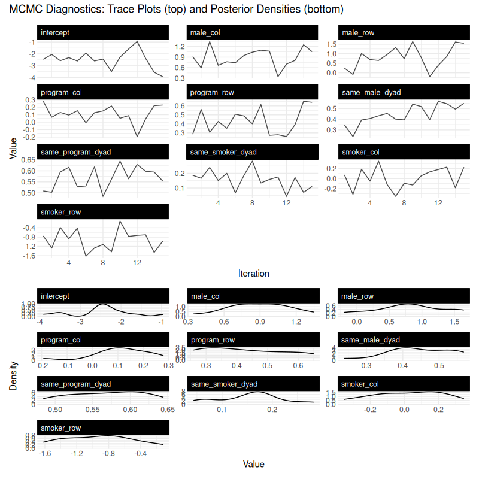

```r
trace_plot(fit, params = "beta")
```

Trace plots should bounce around a stable mean without long-term trends or sticky regions, and density plots should be smooth and unimodal. Numerically, common MCMC checks are **split-$\hat R$ < 1.01** for monitored parameters and **bulk / tail ESS $\ge$ 400 per chain**.

With 15 stored samples, this run cannot meet those thresholds: the number of stored draws caps the ESS, and several $\hat R$ values in the `summarise_draws` table below land well above 1.01. Read the table as a demonstration of how to check these diagnostics, not as evidence of convergence – for a real analysis, lengthen the chain (`burn` in the hundreds, `nscan` in the thousands) until every monitored parameter clears both thresholds. Which parameter mixes worst is seed-dependent in a short chain, so treat this fit as a compact worked example rather than a final diagnostic run.

### Bayesian-ecosystem diagnostics: `posterior::as_draws()`

`lame` registers `as_draws()` methods so any fit drops straight into the Stan-era diagnostic ecosystem (`posterior`, `bayesplot`, `tidybayes`): `posterior::summarise_draws()` gives per-parameter posterior summaries, **split-$\hat R$**, and **bulk / tail ESS** in one call.

```r
library(posterior)
draws <- posterior::as_draws(fit)              # draws_array [iter, chain, var]
posterior::summarise_draws(draws)              # rhat, ess_bulk, ess_tail per param
```

[output not shown]

A single-chain fit like this one has `chain = 1`, so $\hat R$ reduces to within-chain split-$\hat R$; for $\hat R$ across independently initialised chains, see the multi-chain section in the dynamic-effects vignette.

### Goodness of Fit

The `gof_plot` function compares observed network statistics to their posterior predictive distributions: can the model reproduce emergent structural features like degree heterogeneity, transitivity, and reciprocity, not just the dyad-level relationships?

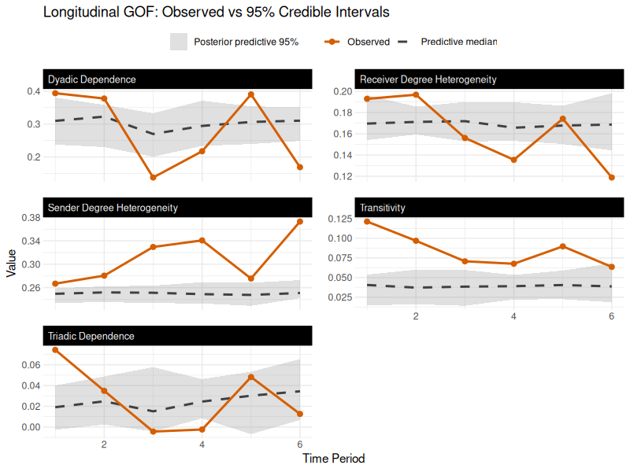

```r
gof_plot(fit)
```

For a longitudinal model, `gof_plot` shows these statistics across time, encoding three series per panel with colour and linetype redundantly: the **observed series is a solid orange line with filled orange points**, the **posterior-predictive median is a dashed dark line**, and the **95% credible interval is a grey ribbon** (width set by `credible.level`). Observed values inside the ribbon are features the model reproduces; values outside flag structure it is missing – itself a substantive finding, not a failure to report.

This is the standard signature of a latent-space model on a friendship network. AME assumes conditional dyadic independence, so triangle closure must be soaked up by clustering of the latent positions; ERGMs model it directly via terms like `gwesp`. The two classes are complementary: ERGM for triangle-closure questions, AME for stable, non-degenerate estimates with explicit actor heterogeneity and a coherent posterior to forecast or simulate from.

#### Posterior-predictive temporal-trend test: `gof_temporal()`

The figure read above is qualitative. `gof_temporal()` gives a scalar check on the temporal *trend* in a chosen statistic: it fits an OLS slope to the observed per-period series, recomputes that slope in posterior-predictive replicate panels drawn via `simulate(fit)`, and returns a two-sided posterior-predictive p-value – near 0 when the observed slope is unreachable under the model, well away from 0 when it is central in the predictive distribution.

```r
# density rises across the panel on net (the network gets denser as
# students settle in, though the trajectory is not monotone), so it is the
# natural temporal-trend target.
gt_density <- gof_temporal(fit, stat = "density", n_rep = 100, seed = 6886)
gt_density   # prints stat, observed slope, n_rep, and the p_pp
```

```
#>
#> ── Temporal-trend posterior-predictive check ──
#>
#> • Statistic: "density"
#> • Observed slope (per-period): 0.025
#> • Replicates: 100
#> • Posterior-predictive p-value (two-sided): 0
#> Observed temporal trend is incompatible with the fitted model.
```

A `p_pp` of 0 says the static fit cannot reproduce the empirical net densification slope (about +0.025 per period in our run) – the expected diagnostic for a model whose parameters are constant across periods, and consistent with the per-period mass shift in `gof_plot()`. `dynamic_beta` or time-varying covariates are the remedy; see the Dynamic Effects vignette.

### Latent Space

The multiplicative effects capture association patterns beyond what the covariates and additive effects explain. We fit `R = 1`, so each student’s sender position ($u_i$) and receiver position ($v_i$) is a single number – and a one-dimensional space should be *plotted* as one dimension (a 2-D scatter of a 1-D space piles every point onto a line and looks degenerate even when the positions are informative). Why not just fit `R = 2`? Extra dimensions are not free: they can absorb signal the dyadic covariates would otherwise pick up, and a one-dimensional space is far easier to display and interpret. Parsimony wins here; to let the data adjudicate a rank choice, compare fits with `loo::loo_compare()` out of sample, as done for `R = 1` versus `R = 0` at the end of this vignette.

The honest display for a 1-D space is a ranked dot plot: every student’s sender and receiver position with a 95% interval, ordered by sender position. The intervals come from the saved U/V draws (`posterior_opts = list(save_UV = TRUE)` in the fit above).

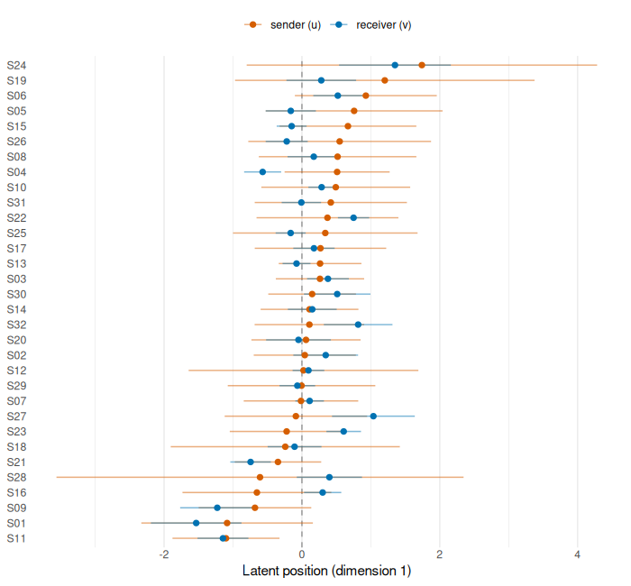

```r
lp1 <- subset(latent_positions(fit), dimension == 1)
ordv <- with(subset(lp1, type == "U"), actor[order(value)])
lp1$actor <- factor(lp1$actor, levels = ordv)

ggplot(lp1, aes(x = value, y = actor, color = type)) +
    geom_vline(xintercept = 0, linetype = 2, color = "grey60") +
    geom_errorbar(aes(xmin = value - 2 * posterior_sd,
                      xmax = value + 2 * posterior_sd),
                  width = 0, alpha = 0.5, orientation = "y") +
    geom_point(size = 1.8) +
    scale_color_manual(values = c(U = "#D55E00", V = "#0072B2"),
                       labels = c(U = "sender (u)", V = "receiver (v)")) +
    labs(x = "Latent position (dimension 1)", y = NULL, color = NULL) +
    theme_bw() +
    theme(panel.border = element_blank(), panel.grid.major.y = element_blank(),
          axis.ticks = element_blank(), legend.position = "top")
```

## Extracting Latent Positions

If you need the estimated latent positions in a tidy format (for custom plots, merging with external data, or exporting to other tools), the `latent_positions()` function returns a data frame:

```r
lp <- latent_positions(fit)
head(lp)
```

```
#>   actor dimension time       value posterior_sd type
#> 1   S01         1    1 -1.08556228    0.6222862    U
#> 2   S02         1    1  0.04186019    0.3704688    U
#> 3   S03         1    1  0.26218435    0.3204626    U
#> 4   S04         1    1  0.51083611    0.3810694    U
#> 5   S05         1    1  0.75744448    0.6417463    U
#> 6   S06         1    1  0.92720709    0.5147045    U
```

Each row gives one actor’s position on one latent dimension at one time point, with a `type` column distinguishing the sender position (`"U"`) from the receiver position (`"V"`). The `posterior_sd` column is populated because the fit saved its U/V draws (`posterior_opts = list(save_UV = TRUE)`); without that option it is `NA` with a one-time message telling you how to refit. A static fit returns a single slice (labelled `time = 1`) that applies to every period; dynamic fits (`dynamic_uv = TRUE`) return each time point separately, and `procrustes_align()` removes the arbitrary per-period rotations so that trajectories across time are interpretable (see the dynamic effects vignette).

## Tidy-data round-trip via netify

`lame` uses the `netify` package for tidy network data: build a netify object from an edgelist and pass it directly to `lame()` or `ame()`. On the way out, `tidy()`, `autoplot()`, and `prediction_draws_long()` give you broom-/ggplot-/marginaleffects-ready output.

### Entry: tidy edgelist → `lame()`

```r
library(netify)

# a tidy edgelist is often how network data arrives. Here we melt the
# Dutch-college wave list back into one (from, to, year, tie) row per
# ordered dyad, carrying a dyadic covariate along for the ride.
edges_long <- do.call(rbind, lapply(seq_along(Y), function(t) {
    Yt  <- Y[[t]]
    idx <- which(!is.na(Yt), arr.ind = TRUE)
    data.frame(
        from = rownames(Yt)[idx[, 1]],
        to   = colnames(Yt)[idx[, 2]],
        year = names(Y)[t],
        tie  = as.integer(Yt[idx]),
        same_program = Xdyad[[t]][, , "same_program"][idx]
    )
}))
head(edges_long)

netlet <- netify::netify(
    edges_long,
    actor1 = "from", actor2 = "to", time = "year",
    weight = "tie", dyad_vars = "same_program",
    symmetric = FALSE, mode = "unipartite",
    missing_to_zero = FALSE,
    output_format = "longit_array"
)

# a netify object drops straight into lame(); reduced iterations here so the
# vignette builds quickly (use burn >= 500, nscan >= 4000 for real analyses).
fit_netlet <- lame(
    netlet,
    family = "binary", R = 1,
    burn = 50, nscan = 200, odens = 5,
    verbose = FALSE
)

# to inspect what lame() will see, to_lame() returns the pieces directly
pieces <- netify::to_lame(netlet, lame = TRUE)
names(pieces)
```

[output not shown]

### Exit: `tidy()`, `autoplot()`, `prediction_draws_long()`

The rest of the round-trip runs against the `fit` object built from the Dutch-college data above:

```r
# tidy(fit) -> term / estimate / std.error / statistic / p.value /
# conf.low / conf.high; one row per coefficient (or per
# coefficient x period for dynamic_beta fits). The generic ships with
# lame so this runs without broom installed; when broom is on the path
# `broom::tidy(fit)` dispatches to the same method via
# generics::tidy registration.
tidy(fit)
```

```
#> # A tibble: 10 × 7
#>    term              estimate std.error statistic    p.value conf.low conf.high
#>    <chr>                <dbl>     <dbl>     <dbl>      <dbl>    <dbl>     <dbl>
#>  1 intercept          -2.48      0.751    -3.30   0.000984    -3.79      -1.18
#>  2 male_row            0.812     0.573     1.42   0.156       -0.163      1.64
#>  3 smoker_row         -0.926     0.435    -2.13   0.0335      -1.56      -0.210
#>  4 program_row         0.429     0.140     3.06   0.00219      0.264      0.647
#>  5 male_col            0.890     0.264     3.36   0.000768     0.433      1.31
#>  6 smoker_col          0.0128    0.210     0.0608 0.952       -0.341      0.306
#>  7 program_col         0.110     0.116     0.950  0.342       -0.129      0.262
#>  8 same_male_dyad      0.445     0.0916    4.86   0.00000117   0.276      0.561
#>  9 same_smoker_dyad    0.156     0.0643    2.42   0.0153       0.0515     0.267
#> 10 same_program_dyad   0.569     0.0498   11.4    0            0.491      0.639
```

### Coefficient tables: `glance()` + `tidy()` -> `modelsummary` / `gt` / `kableExtra`

Because `tidy()` and `glance()` are registered against their `generics` counterparts, any broom-aware table package consumes a `lame` fit directly – most compactly `modelsummary::modelsummary(fit)`:

```r
# glance() returns the one-row model summary modelsummary uses for its
# lower panel: nobs, n_actors, n_periods, n_stored, family, mode, R,
# dynamic_uv / dynamic_ab / dynamic_beta, elpd_loo (NA unless save_log_lik=TRUE).
broom::glance(fit)

# pass the fit straight to modelsummary -- tidy() drives the upper
# (coefficients) panel, glance() drives the lower (GOF) panel.
modelsummary::modelsummary(
    list("Dutch college" = fit),
    statistic = "conf.int",
    gof_map = c("nobs", "n_actors", "n_periods", "n_stored",
                "family", "R", "dynamic_uv", "dynamic_ab")
)
```

[output not shown]

Multiple fits compose into a side-by-side table via a named list, one column per fit. Below we compare the full specification against a no-latent-space variant (`R = 0`):

```r
fit_noUV <- lame(
    Y = Y, Xdyad = Xdyad, Xrow = Xrow, Xcol = Xcol,
    family = "binary", rvar = TRUE, cvar = TRUE, dcor = TRUE,
    R = 0,                          # no latent space
    symmetric = FALSE,
    burn = 30, nscan = 150, odens = 10,
    save_log_lik = TRUE,            # reused by loo_compare() below
    verbose = FALSE, plot = FALSE
)
```

```r
modelsummary::modelsummary(
    list("AME (R = 1)" = fit, "Additive only (R = 0)" = fit_noUV),
    statistic = "conf.int",
    gof_map = c("nobs", "n_actors", "n_periods", "n_stored",
                "family", "R", "dynamic_uv", "dynamic_ab")
)
```

[output not shown]

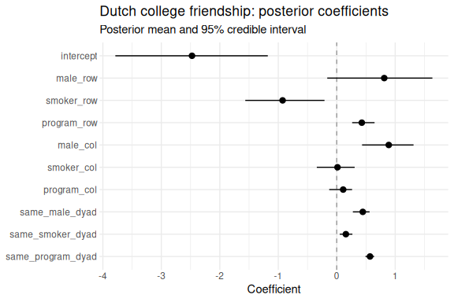

```r
# autoplot.lame returns a horizontal coefplot for static fits and a
# ribbon-per-period for dynamic_beta fits, so the same call works for
# both. ggplot layers compose on top.
autoplot(fit) +
    ggtitle("Dutch college friendship: posterior coefficients")
```

The coefplot is the visual form of the `tidy(fit)` table above: the three homophily terms sit clear of the dashed zero line – `same_program` largest (0.57), `same_male` next (0.45), `same_smoker` smallest (0.16) – while the nodal terms are mixed, with `smoker_col` and `program_col` straddling the line. The same generic dispatches on `which = "uv"` (latent positions – the ranked dot plot in the Latent Space section above) and `which = "ab"` (sender / receiver random effects):

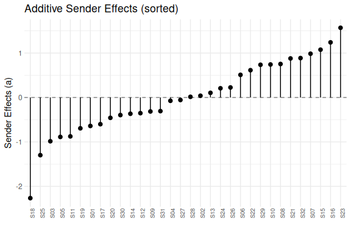

```r
# which = "ab" delegates to ab_plot() (sender side by default; use
# ab_plot(fit, effect = "receiver") for the column side). Each lollipop
# is a student's sender random effect a_i: the longest positive stems
# are students who nominate far more friends than their covariates
# predict -- the heterogeneity that va summarises as one number.
autoplot(fit, which = "ab")
```

```r
# prediction_draws_long() returns a long-format data frame with
# .chain / .iteration / .draw / period / period_label / i / j /
# actor_i / actor_j / .value -- ready for tidybayes / marginaleffects.
pdl <- prediction_draws_long(fit, type = "response", n_draws = 50)
# the diagonal (i == j) is a self-tie, undefined in a friendship network, but
# the linear predictor is still numerically defined there -- drop it so the
# frame covers only real (off-diagonal) pairs.
pdl <- pdl[pdl$i != pdl$j, ]
head(pdl, 3)
```

```
#> # A tibble: 3 × 10
#>   .chain .iteration .draw period period_label     i     j actor_i actor_j
#>    <int>      <int> <int>  <int> <chr>        <int> <int> <chr>   <chr>
#> 1      1          1     1      1 t2               2     1 S02     S01
#> 2      1          1     1      1 t2               3     1 S03     S01
#> 3      1          1     1      1 t2               4     1 S04     S01
#> # ℹ 1 more variable: .value <dbl>
```

```r
dim(pdl)
```

```
#> [1] 297600     10
```

Because the `.chain` / `.iteration` / `.draw` / `.value` columns follow the `tidybayes` / `marginaleffects` convention, this frame composes directly with `ggdist`, `tidybayes`, and `marginaleffects` – no reshaping step needed.

## Model comparison: `loo::loo_compare()` as a one-liner

Does the latent space earn its keep over additive effects alone? The standard out-of-sample yardstick is the expected log pointwise predictive density (`elpd_loo`) from `loo::loo()`, which requires `save_log_lik = TRUE` at fit time; the mechanics (and the Pareto-$k$ diagnostics to read before trusting any `elpd` number) are covered in Your First AME Model. Both fits above already carry the pointwise log-likelihood, so `loo::loo_compare()` ranks them in one call:

```r
# both fits already carry save_log_lik = TRUE, so this reuses them -- no
# refitting. Pass a NAMED list so the rows are labelled by model rather
# than model1/model2.
cmp <- loo::loo_compare(list(no_latent = loo::loo(fit_noUV),
                             latent_R1 = loo::loo(fit)))
cmp
```

```
#>           elpd_diff se_diff
#> latent_R1    0.0       0.0
#> no_latent -112.6      15.4
```

**How to read the output.** The top row is the preferred model (`elpd_diff = 0`); each subsequent row reports the elpd *difference* relative to it, with a standard error. Here `latent_R1` is preferred, beating `no_latent` by about `112.6` elpd units (SE `15.4`); a ratio of `|elpd_diff|/se_diff` near or above 2 is a reasonably confident preference, so the latent space is doing real predictive work on this network. When `|elpd_diff|` is instead close to its SE, the simpler model is the defensible choice.

## Reproducibility: `sessionInfo()` and `renv.lock`

An analysis a reviewer (or your future self) can reproduce records the seed and the package versions it was fit under. The pattern:

```r
fit <- lame(..., seed = 6886)          # the sampler seed lives in lame()
saveRDS(list(fit = fit, session = sessionInfo()),
        file = "lame_fit_replication.rds")
```

## What’s Next?

This vignette covered the core workflow: fitting, convergence, GOF, and visualization. For more specialized topics:

- **Single networks (no time series)?** See Your First AME Model for a detailed cross-sectional walkthrough
- **Two types of nodes?** See Bipartite Networks
- **Evolving network structure?** See Dynamic Effects
- **Just want the quick version?** See Getting Started

**References**:

Hoff, PD (2021) Additive and Multiplicative Effects Network Models. Statistical Science 36, 34–50.

van de Bunt, G. G., van Duijn, M. A. J., & Snijders, T. A. B. (1999). Friendship networks through time: An actor-oriented dynamic statistical network model. *Computational & Mathematical Organization Theory*, 5(2), 167–192.

Minhas, S., Dorff, C., Gallop, M. B., Foster, M., Liu, H., Tellez, J., & Ward, M. D. (2022). Taking dyads seriously. Political Science Research and Methods, 10(4), 703–721. doi:10.1017/psrm.2021.56